# Usando Regressão Linear para Explicar a votação de Deputados

Paulo Vinicius Soares

29 de novembro de 2017

```r
library(readr)
library(knitr)
library(tidyverse)
```

# Introdução

Antes, vamos importar os dados referentes às eleições de 2014. Antes de utilizar os dados, é necessário fazer alguns ajustes, tais quais tratamento de NAs e alterar os tipos de algumas variáveis de *factor* para *character*.

O tratamento de NAs escolhido para essa análise foi substituir todos os NAs pela mediana de valores daquela coluna para evitar a perda de dados.

```r
eleicoes2014 <- read.csv("../database/eleicoes2014.csv", encoding = "latin1") %>%
  mutate(nome = as.character(nome),
         UF = as.character(UF),
         partido = as.character(partido),
         setor_economico_receita = as.character(setor_economico_receita),
         setor_economico_despesa = as.character(setor_economico_despesa),
         cargo = as.character(cargo),
         sexo = as.character(sexo),
         grau = as.character(grau),
         estado_civil = as.character(estado_civil)
         )

eleicoes2014$recursos_de_outros_candidatos.comites <- replace(eleicoes2014$recursos_de_outros_candidatos.comites, is.na(eleicoes2014$recursos_de_outros_candidatos.comites), median(eleicoes2014$recursos_de_outros_candidatos.comites, na.rm = TRUE))

eleicoes2014$recursos_de_partidos <- replace(eleicoes2014$recursos_de_partidos, is.na(eleicoes2014$recursos_de_partidos), median(eleicoes2014$recursos_de_partidos, na.rm = TRUE))

eleicoes2014$recursos_de_pessoas_físicas <- replace(eleicoes2014$recursos_de_pessoas_físicas, is.na(eleicoes2014$recursos_de_pessoas_físicas), median(eleicoes2014$recursos_de_pessoas_físicas, na.rm = TRUE))

eleicoes2014$recursos_de_pessoas_juridicas <- replace(eleicoes2014$recursos_de_pessoas_juridicas, is.na(eleicoes2014$recursos_de_pessoas_juridicas), median(eleicoes2014$recursos_de_pessoas_juridicas, na.rm = TRUE))

eleicoes2014$recursos_proprios <- replace(eleicoes2014$recursos_proprios, is.na(eleicoes2014$recursos_proprios), median(eleicoes2014$recursos_proprios, na.rm = TRUE))
```

# Perguntas

Nesse primeiro momento, a análise terá caráter exploratório. Vamos verificar a influência das variáveis na variável de saída **votos**, além de analisar outros pontos referentes aos resíduos e a geração de um modelo usando regressão linear múltipla.

## 1. Um modelo de regressão múltipla com todas as variáveis é plausível para explicar a variação em y (número de votos)?

Primeiro, vejamos o panorama geral dos dados, ou seja, quais colunas o *data frame* contém e o que significam.

```r
eleicoes2014 %>%
  glimpse()
```

```
## Observations: 4,152
## Variables: 26
## $ sequencial_candidato                  <dbl> 1.0e+11, 5.0e+10, 2.5e+1...
## $ nome                                  <chr> "LOURIVAL MENDES DA FONS...
## $ numero_cadidato                       <int> 7070, 1540, 3333, 1522, ...
## $ UF                                    <chr> "MA", "BA", "SP", "MS", ...
## $ partido                               <chr> "PT do B", "PMDB", "PMN"...
## $ setor_economico_receita               <chr> "#NULO", "#NULO", "Ativi...
## $ quantidade_doacoes                    <int> 23, 5, 8, 48, 11, 9, 20,...
## $ quantidade_doadores                   <int> 14, 5, 3, 25, 6, 7, 11, ...
## $ total_receita                         <dbl> 151566.39, 161770.58, 27...
## $ media_receita                         <dbl> 6589.8430, 32354.1160, 3...
## $ recursos_de_outros_candidatos.comites <dbl> 4217.50, 50000.00, 4217....
## $ recursos_de_partidos                  <dbl> 6325.485, 103670.580, 24...
## $ recursos_de_pessoas_físicas           <dbl> 92350.00, 8100.00, 4550....
## $ recursos_de_pessoas_juridicas         <dbl> 20000.00, 28086.00, 2808...
## $ recursos_proprios                     <dbl> 39216.39, 5019.35, 250.0...
## $ votos                                 <int> 27277, 9477, 2943, 4421,...
## $ quantidade_despesas                   <int> 72, 13, 8, 245, 18, 23, ...
## $ quantidade_fornecedores               <int> 26, 7, 3, 139, 13, 9, 23...
## $ total_despesa                         <dbl> 151566.39, 161770.58, 27...
## $ media_despesa                         <dbl> 2105.0887, 12443.8908, 3...
## $ setor_economico_despesa               <chr> "#NULO", "Impressão de m...
## $ cargo                                 <chr> "DEPUTADO FEDERAL", "DEP...
## $ idade                                 <int> 59, 58, 61, 36, 26, 40, ...
## $ sexo                                  <chr> "MASCULINO", "MASCULINO"...
## $ grau                                  <chr> "SUPERIOR COMPLETO", "EN...
## $ estado_civil                          <chr> "CASADO(A)", "DIVORCIADO...
```

Existem 26 variáveis no nosso *data frame* e o seus significados são:

- “Sequencial_candidato” : (character) id do candidato
- “Nome”:
- “Numero_cadidato”: (character)
- “UF”: (character)
- “Partido”: (character)
- “Setor_economico_receita” : (character) setor econômico que mais doou (em quantidade de vezes) para o candidato;
- “Quantidade_doacoes”: (integer)
- “Quantidade_doadores”: (integer) número de doadores diferentes
- “Total_receita”: (double) soma em R$ das doações
- “Media_receita”: (double) média das doações
- “recursos_de_outros_candidatos/comites”: (double) quantia em R$ das doações provenientes de outros candidatos ou comite partidário
- “Recursos_de_partidos”: (double) quantia em R$ das doações provenientes de outros candidatos ou partidos
- “Recursos_de_pessoas_físicas”: (double) quantia em R$ das doações provenientes de outros CPFs
- “Recursos_de_pessoas_juridicas”: (double) quantia em R$ das doações provenientes de outros CNPJ
- “Recursos_proprios”: (double) quantia em R$ das doações provenientes do próprio candidato
- “Votos”: (integer) variável alvo. Se refere ao número de votos na campanha de 2014
- “Quantidade_despesas”: (integer)
- “Quantidade_fornecedores”: (integer) número de fornecedores/despesas diferentes
- “Total_despesa”: (double) soma em R$ das despesas de campanha
- “Media_despesa”: (double) média das despesas de campanha
- “Setor_economico_despesa”: (character) setor econômico que o candidato mais gastou na campanha (em quantidade de vezes);
- “Cargo”: (character)
- “Idade” : (int)
- “Sexo”: (character)
- “Grau”: (character)
- “Estado_civil”: (character)

De cara percebemos que algumas variáveis **não influenciam** na variável de saída, pois são apenas para identificação do deputado, tal como *nome*, *sequencial_candidato* e *numero_candidato*. *Cargo* também não influencia no modelo, haja visto que todos os cargos são os mesmos (deputado federal). Algumas variáveis são lidas e tratadas como fatores de muitos níveis no modelo de regressão linear, o que atrapalha a leitura e interpretação deste. Por esse motivo, essas variáveis também serão desconsideradas: *setor_economico_despesa* e *setor_economico_receita*.

Podemos criar um modelo de regressão linear sem essas variáveis e ver o que acontece.

```r
eleicoes_filtradas <- eleicoes2014 %>%
  select(-nome, -sequencial_candidato, -numero_cadidato, -cargo, -setor_economico_despesa, -setor_economico_receita)

modelo <- lm(data = eleicoes_filtradas, votos ~ .)

modelo %>%
  summary()
```

```
##
## Call:
## lm(formula = votos ~ ., data = eleicoes_filtradas)
##
## Residuals:
##     Min      1Q  Median      3Q     Max
## -300288   -7949   -1395    4009 1228948
##
## Coefficients:
##                                         Estimate Std. Error t value
## (Intercept)                           -2.875e+03  6.888e+03  -0.417
## UFAL                                   1.589e+04  6.429e+03   2.471
## UFAM                                   1.485e+04  6.755e+03   2.198
## UFAP                                   8.568e+03  6.281e+03   1.364
## UFBA                                   1.950e+04  5.568e+03   3.502
## UFCE                                   2.254e+04  5.720e+03   3.941
## UFDF                                   9.792e+03  6.030e+03   1.624
## UFES                                   1.392e+04  5.940e+03   2.344
## UFGO                                   1.343e+04  6.535e+03   2.056
## UFMA                                   2.206e+04  5.795e+03   3.806
## UFMG                                   1.525e+04  5.254e+03   2.903
## UFMS                                   2.673e+03  6.021e+03   0.444
## UFMT                                   9.148e+03  6.579e+03   1.391
## UFPA                                   2.037e+04  5.800e+03   3.512
## UFPB                                   2.534e+04  6.468e+03   3.917
## UFPE                                   2.228e+04  6.016e+03   3.704
## UFPI                                   1.609e+04  6.541e+03   2.461
## UFPR                                   1.749e+04  5.504e+03   3.177
## UFRJ                                   1.381e+04  5.166e+03   2.674
## UFRN                                   2.221e+04  6.487e+03   3.424
## UFRO                                   6.938e+03  6.512e+03   1.065
## UFRR                                   8.562e+03  6.422e+03   1.333
## UFRS                                   1.769e+04  5.479e+03   3.228
## UFSC                                   2.166e+04  6.161e+03   3.516
## UFSE                                   2.057e+04  6.788e+03   3.031
## UFSP                                   1.514e+04  5.120e+03   2.957
## UFTO                                   4.493e+03  7.110e+03   0.632
## partidoPCB                            -6.112e+03  7.476e+03  -0.818
## partidoPC do B                        -1.181e+04  5.388e+03  -2.192
## partidoPCO                            -4.536e+03  1.197e+04  -0.379
```

[output cut: 128 more lines]

```
## grauENSINO MÉDIO COMPLETO             0.706088
## grauENSINO MÉDIO INCOMPLETO           0.754470
## grauLÊ E ESCREVE                      0.943217
## grauSUPERIOR COMPLETO                 0.167257
## grauSUPERIOR INCOMPLETO               0.608630
## estado_civilDIVORCIADO(A)             0.952637
## estado_civilSEPARADO(A) JUDICIALMENTE 0.223417
## estado_civilSOLTEIRO(A)               0.778043
## estado_civilVIÚVO(A)                  0.089704 .
## ---
## Signif. codes:  0 '***' 0.001 '**' 0.01 '*' 0.05 '.' 0.1 ' ' 1
##
## Residual standard error: 32230 on 4069 degrees of freedom
## Multiple R-squared:  0.5034, Adjusted R-squared:  0.4934
## F-statistic:  50.3 on 82 and 4069 DF,  p-value: < 2.2e-16
```

## 2. Todas as variáveis são úteis para o modelo de regressão? Há variáveis redudantes?

Não, algumas variáveis servem apenas para identificar quem é o deputado, como um ID. Inclusive, estes campo são redundantes: O *numero_cadidato*, o *sequencial_cadidato*. O nome também não é útil para a variável de saída nesse modelo.

Formalizando um pouco mais, podemos utilizar um método de busca exaustiva no contexto de *seleção de variáveis*. Essa seleção de variáveis diagnostica quais variáveis estão associadas à variável resposta.

Por questões de simplicidade na geração do modelo utilizando esse método vamos desconsiderar *partidos* e *estados (UF)*, pois eles contém muitos níveis de fator fazendo com que haja demora no processamento dos dados.

```r
library(leaps)

eleicoes_filtradas <- eleicoes_filtradas %>%
  select(-partido, -UF)

regsubsets.out <-
    regsubsets(votos ~ .,
               data = eleicoes_filtradas,
               nbest = 1,       # 1 único modelo para cada cojunto de preditores
               nvmax = NULL,    # NULL para não haver limite no número de variáveis preditoras
               force.in = NULL, force.out = NULL,
               method = "exhaustive",
               really.big=T)

summary.out <- summary(regsubsets.out)
summary.out
```

```
## Subset selection object
## Call: regsubsets.formula(votos ~ ., data = eleicoes_filtradas, nbest = 1,
##     nvmax = NULL, force.in = NULL, force.out = NULL, method = "exhaustive",
##     really.big = T)
## 25 Variables  (and intercept)
##                                       Forced in Forced out
## quantidade_doacoes                        FALSE      FALSE
## quantidade_doadores                       FALSE      FALSE
## total_receita                             FALSE      FALSE
## media_receita                             FALSE      FALSE
## recursos_de_outros_candidatos.comites     FALSE      FALSE
## recursos_de_partidos                      FALSE      FALSE
## recursos_de_pessoas_físicas               FALSE      FALSE
## recursos_de_pessoas_juridicas             FALSE      FALSE
## recursos_proprios                         FALSE      FALSE
```

[output cut: 304 more lines]

A chamada ao `summary.out` mostra qual o melhor modelo para cada tamanho do subconjunto de variáveis. O melhor modelo é definido pelo R² ajustado - que é a capacidade que o modelo tem de explicar os dados - e *p valor*.

Verificando qual modelo possui o melhor R², temos:

```r
which.max(summary.out$adjr2)
```

```
## [1] 17
```

Quais variáveis estão presentes nesse modelo?

```r
var <- summary.out$which[17,]
var
```

```
##                           (Intercept)
##                                  TRUE
##                    quantidade_doacoes
##                                 FALSE
##                   quantidade_doadores
##                                  TRUE
##                         total_receita
##                                  TRUE
##                         media_receita
##                                  TRUE
## recursos_de_outros_candidatos.comites
##                                  TRUE
##                  recursos_de_partidos
##                                  TRUE
##           recursos_de_pessoas_físicas
##                                  TRUE
##         recursos_de_pessoas_juridicas
##                                  TRUE
##                     recursos_proprios
##                                  TRUE
##                   quantidade_despesas
##                                  TRUE
##               quantidade_fornecedores
##                                  TRUE
##                         total_despesa
##                                  TRUE
##                         media_despesa
##                                  TRUE
##                                 idade
##                                 FALSE
##                         sexoMASCULINO
##                                  TRUE
##     grauENSINO FUNDAMENTAL INCOMPLETO
##                                 FALSE
##             grauENSINO MÉDIO COMPLETO
##                                 FALSE
##           grauENSINO MÉDIO INCOMPLETO
##                                 FALSE
##                      grauLÊ E ESCREVE
##                                 FALSE
##                 grauSUPERIOR COMPLETO
##                                  TRUE
##               grauSUPERIOR INCOMPLETO
##                                  TRUE
##             estado_civilDIVORCIADO(A)
##                                 FALSE
## estado_civilSEPARADO(A) JUDICIALMENTE
##                                  TRUE
##               estado_civilSOLTEIRO(A)
##                                 FALSE
##                  estado_civilVIÚVO(A)
##                                  TRUE
```

```r
indexes <- which(summary.out$which[17,])
not_indexes <- which(!summary.out$which[17,])

var_true <- names(var)[indexes]
var_false <- names(var)[not_indexes]
```

No total se encontram 17 variáveis que têm alguma influência na variável de saída.

```r
var_true
```

```
##  [1] "(Intercept)"
##  [2] "quantidade_doadores"
##  [3] "total_receita"
##  [4] "media_receita"
##  [5] "recursos_de_outros_candidatos.comites"
##  [6] "recursos_de_partidos"
##  [7] "recursos_de_pessoas_físicas"
##  [8] "recursos_de_pessoas_juridicas"
##  [9] "recursos_proprios"
## [10] "quantidade_despesas"
## [11] "quantidade_fornecedores"
## [12] "total_despesa"
## [13] "media_despesa"
## [14] "sexoMASCULINO"
## [15] "grauSUPERIOR COMPLETO"
## [16] "grauSUPERIOR INCOMPLETO"
## [17] "estado_civilSEPARADO(A) JUDICIALMENTE"
## [18] "estado_civilVIÚVO(A)"
```

As variáveis que não influenciam em *votos*:

```r
var_false
```

```
## [1] "quantidade_doacoes"                "idade"
## [3] "grauENSINO FUNDAMENTAL INCOMPLETO" "grauENSINO MÉDIO COMPLETO"
## [5] "grauENSINO MÉDIO INCOMPLETO"       "grauLÊ E ESCREVE"
## [7] "estado_civilDIVORCIADO(A)"         "estado_civilSOLTEIRO(A)"
```

Vamos construir o modelo sem as variáveis que não influenciam em *votos*. Como *grau* e *estado_civil* possuem níveis de fatores que também influenciam em *votos*, vamos conservar essas duas variáveis.

```r
modelo_melhorado <- eleicoes_filtradas %>%
  select(
    -quantidade_doacoes, -idade
  )

modelo_agora_vai <- lm(formula = votos ~ ., modelo_melhorado)
summary(modelo_agora_vai)
```

```
##
## Call:
## lm(formula = votos ~ ., data = modelo_melhorado)
##
## Residuals:
##     Min      1Q  Median      3Q     Max
## -303830   -6617   -1168    2635 1243899
##
## Coefficients:
##                                         Estimate Std. Error t value
## (Intercept)                            7.397e+03  2.836e+03   2.608
## quantidade_doadores                    2.347e+02  2.397e+01   9.789
## total_receita                          3.511e-01  3.952e-02   8.884
## media_receita                          3.973e-01  4.906e-02   8.099
## recursos_de_outros_candidatos.comites -2.209e-01  3.963e-02  -5.574
## recursos_de_partidos                  -3.144e-01  3.880e-02  -8.103
## recursos_de_pessoas_físicas           -3.120e-01  4.003e-02  -7.795
## recursos_de_pessoas_juridicas         -3.026e-01  3.873e-02  -7.812
## recursos_proprios                     -3.269e-01  3.906e-02  -8.371
## quantidade_despesas                    4.810e+01  4.214e+00  11.415
## quantidade_fornecedores               -5.481e+01  6.049e+00  -9.061
## total_despesa                         -2.821e-02  7.390e-03  -3.818
## media_despesa                          2.015e+00  3.941e-01   5.114
## sexoMASCULINO                          1.900e+03  1.185e+03   1.604
## grauENSINO FUNDAMENTAL INCOMPLETO      2.030e+03  3.877e+03   0.524
## grauENSINO MÉDIO COMPLETO              1.387e+03  2.393e+03   0.580
## grauENSINO MÉDIO INCOMPLETO            1.117e+03  3.905e+03   0.286
## grauLÊ E ESCREVE                       1.711e+03  7.590e+03   0.225
## grauSUPERIOR COMPLETO                  3.485e+03  2.286e+03   1.524
## grauSUPERIOR INCOMPLETO               -7.429e+02  2.649e+03  -0.280
## estado_civilDIVORCIADO(A)             -1.312e+03  1.660e+03  -0.790
## estado_civilSEPARADO(A) JUDICIALMENTE -4.472e+03  3.705e+03  -1.207
## estado_civilSOLTEIRO(A)               -1.088e+03  1.204e+03  -0.904
## estado_civilVIÚVO(A)                  -5.746e+03  3.693e+03  -1.556
##                                       Pr(>|t|)
## (Intercept)                           0.009133 **
## quantidade_doadores                    < 2e-16 ***
## total_receita                          < 2e-16 ***
## media_receita                         7.22e-16 ***
## recursos_de_outros_candidatos.comites 2.65e-08 ***
```

[output cut: 10 more lines]

```
## grauENSINO MÉDIO COMPLETO             0.562107
## grauENSINO MÉDIO INCOMPLETO           0.774881
## grauLÊ E ESCREVE                      0.821690
## grauSUPERIOR COMPLETO                 0.127533
## grauSUPERIOR INCOMPLETO               0.779133
## estado_civilDIVORCIADO(A)             0.429311
## estado_civilSEPARADO(A) JUDICIALMENTE 0.227504
## estado_civilSOLTEIRO(A)               0.366272
## estado_civilVIÚVO(A)                  0.119783
## ---
## Signif. codes:  0 '***' 0.001 '**' 0.01 '*' 0.05 '.' 0.1 ' ' 1
##
## Residual standard error: 32460 on 4128 degrees of freedom
## Multiple R-squared:  0.489,  Adjusted R-squared:  0.4861
## F-statistic: 171.7 on 23 and 4128 DF,  p-value: < 2.2e-16
```

## 3. No caso de haver variáveis pouco explicativas e/ou redudantes, construa um novo modelo sem essas variáveis e o compare ao modelo com todas as variáveis (e.g. em termos de R2 e RSE).

Com o modelo construído anteriormente, apesar de *sexo*, *grau* e *estado_civil* serem considerados relevantes, após uma análise no segundo modelo podemos perceber que seus *p valores* são muito altos, de forma que podemos criar um novo modelo sem essas variáveis.

```r
modelo_final <- modelo_melhorado %>%
  select(
    -sexo, -grau, -estado_civil
  )

modelo_agora_vai2 <- lm(formula = votos ~ ., modelo_final)
summary(modelo_agora_vai2)
```

```
##
## Call:
## lm(formula = votos ~ ., data = modelo_final)
##
## Residuals:
##     Min      1Q  Median      3Q     Max
## -308197   -6631    -834    2121 1245139
##
## Coefficients:
##                                         Estimate Std. Error t value
## (Intercept)                            1.087e+04  1.441e+03   7.543
## quantidade_doadores                    2.395e+02  2.395e+01   9.999
## total_receita                          3.776e-01  3.873e-02   9.749
## media_receita                          4.076e-01  4.892e-02   8.332
## recursos_de_outros_candidatos.comites -2.474e-01  3.884e-02  -6.369
## recursos_de_partidos                  -3.412e-01  3.798e-02  -8.983
## recursos_de_pessoas_físicas           -3.380e-01  3.926e-02  -8.610
## recursos_de_pessoas_juridicas         -3.291e-01  3.793e-02  -8.677
## recursos_proprios                     -3.538e-01  3.825e-02  -9.249
## quantidade_despesas                    4.821e+01  4.212e+00  11.446
## quantidade_fornecedores               -5.506e+01  6.046e+00  -9.107
## total_despesa                         -2.803e-02  7.395e-03  -3.791
## media_despesa                          2.066e+00  3.936e-01   5.249
##                                       Pr(>|t|)
## (Intercept)                           5.63e-14 ***
## quantidade_doadores                    < 2e-16 ***
## total_receita                          < 2e-16 ***
## media_receita                          < 2e-16 ***
## recursos_de_outros_candidatos.comites 2.12e-10 ***
## recursos_de_partidos                   < 2e-16 ***
## recursos_de_pessoas_físicas            < 2e-16 ***
## recursos_de_pessoas_juridicas          < 2e-16 ***
## recursos_proprios                      < 2e-16 ***
## quantidade_despesas                    < 2e-16 ***
## quantidade_fornecedores                < 2e-16 ***
## total_despesa                         0.000152 ***
## media_despesa                         1.61e-07 ***
## ---
## Signif. codes:  0 '***' 0.001 '**' 0.01 '*' 0.05 '.' 0.1 ' ' 1
##
## Residual standard error: 32490 on 4139 degrees of freedom
## Multiple R-squared:  0.4868, Adjusted R-squared:  0.4854
## F-statistic: 327.2 on 12 and 4139 DF,  p-value: < 2.2e-16
```

Comparando o primeiro modelo gerado e o último, temos:

### Análise da estatística F

Para os dois casos, o F possui um valor maior que 1 e o tamanho da amostra é maior que o número de preditores. A estatística F revela se há relação entre alguma variável preditora e a variável de saída. Para o primeiro caso, `F = 50.3` e para o segundo caso, `F = 327.2`.

### Análise do p valor

Os *p valores* do primeiro modelo em algumas variáveis é bem alto, indicando uma alta probabilidade de que estas não influenciem na variável de saída. É o caso de alguns partidos, *idade*, *sexo*, *grau* e *estado civil*.

No último modelo, todos os *p valores* das variáveis estão muito baixos, o que apontam a influência muito forte destas na variável de saída.

### Análise do RSE

Para o primeiro modelo, temos `Residual standard error: 32230 on 4069 degrees of freedom` contra `Residual standard error: 32490 on 4139 degrees of freedom` do modelo final. Embora o segundo modelo apresente um *RSE* maior, este apresenta mais graus de liberdade.

### Análise do R² e R² ajustado

O R² é o quadrado da correlação entre variável resposta e o modelo linear ajustado e mede a fração da variância explicada. Embora o primeiro modelo apresente um valor R² maior - `Multiple R-squared: 0.5034, Adjusted R-squared: 0.4934` contra `Multiple R-squared: 0.4868, Adjusted R-squared: 0.4854` do modelo final - Isso não significa que o modelo final está incorreto ou menos preciso, mostra apenas que o modelo se adequa menos aos dados, porém ganha em poder de generalização. Não devemos considerar apenas o R² para a seleção de variáveis, mas sempre aliar essa leitura ao *p valor*.

## 4. Analise plots de resíduos e verifique se há tendências nos erros.

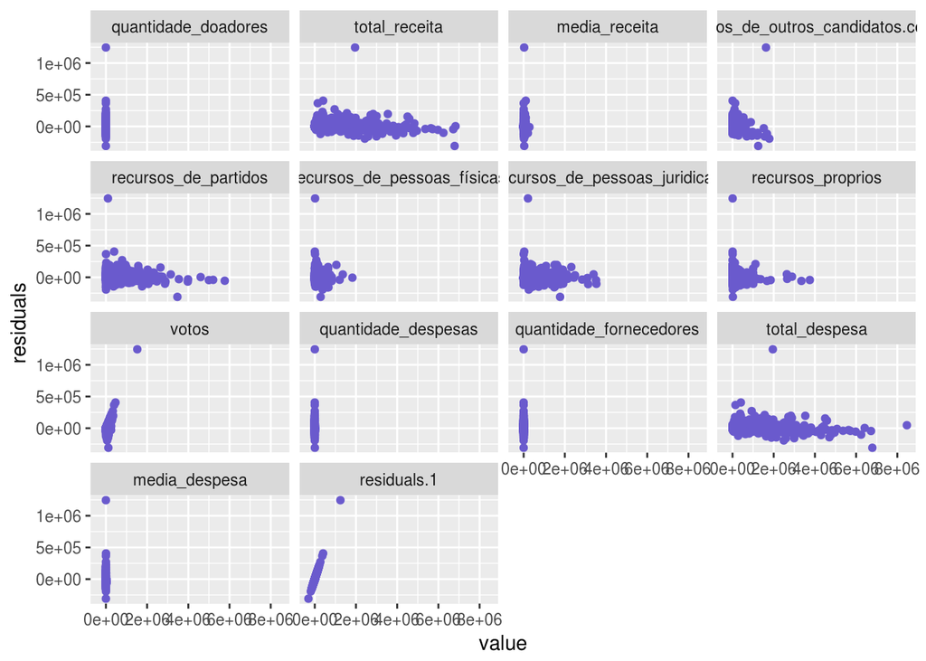

```r
modelo_final$residuals <- residuals(modelo_agora_vai2)

nomes_variaveis <- c(names(modelo_final), "residuals")

plotDF <- reshape2::melt(modelo_final[, nomes_variaveis], id="residuals")

ggplot(plotDF, aes(x=value, y=residuals)) +
  geom_point(color="slateblue") + facet_wrap(~variable)
```

Os gráficos de resíduos apontam alguns outliers, mas em geral os pontos se concentram próximos à 0 no eixo y, o que indica que o modelo não subestima ou superestima os valores.

## 5. Quais variáveis conseguem explicar melhor o número de votos?

Pela análise dos *p valores* podemos perceber que os valores mais baixos são das variáveis: *quantidade_doadores*, *total_receita*, *media_receita*,*recursos_de_outros_candidatos.comites*, *recursos_de_partidos*, *recursos_de_pessoas_fisicas*, *recursos_de_pessoas_juridicas*, *recursos_proprios*, *quantidade_despesas*, *quantidade_fornecedores*, *total_despesa* e *media_despesa*. O *p valor* é um forte indicador de correlação entre a variável de saída e a variável analisada, pois aponta a probabilidade dessa correlação entre as variáveis ser aleatória. Ou seja, quanto menor essa probabilidade, maior a chance da correlação ser relevante ou existente.